# ETH-USD

## ETH-USD today is +0200, 2025-11-06, 03:51:05

This crypto forecast was generated by gemini-2.0-flash API

## Daily Chart

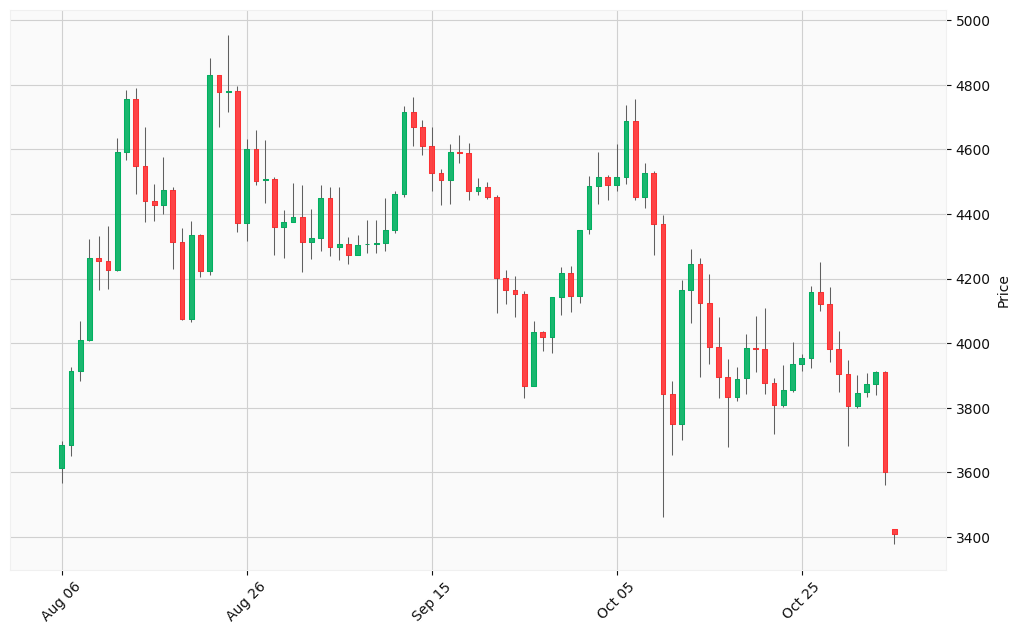

## Hourly Chart

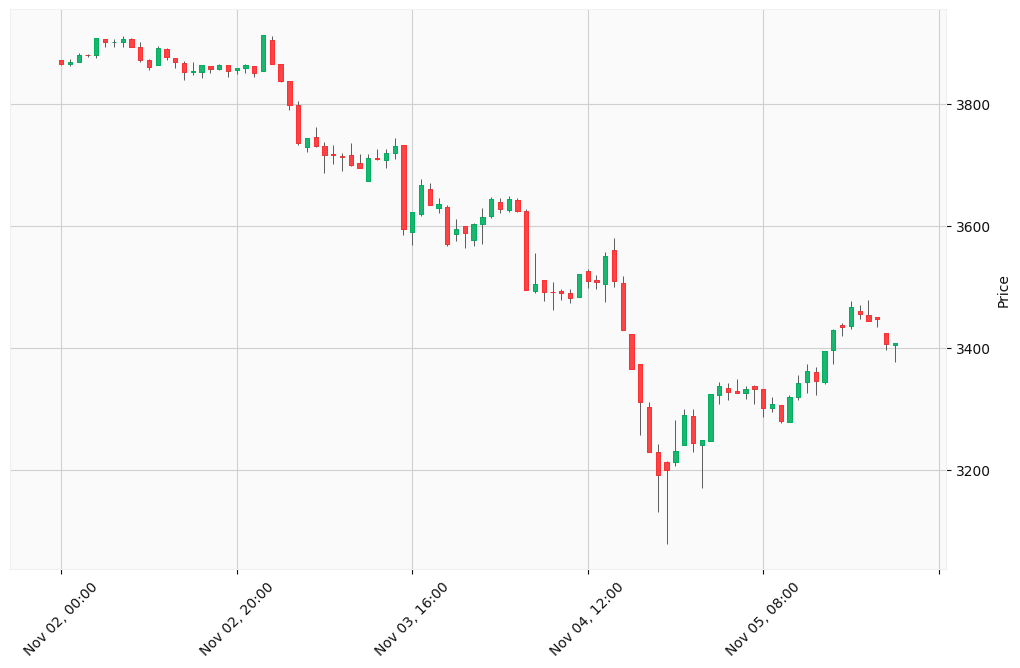

Okay, I will analyze the provided ETH-USD charts (daily for the last three months and hourly for the last five days) and generate buy and sell signals based on the steps you’ve outlined. I will use technical analysis on the provided data, consider potential market scenarios, and integrate external factors via web searches.

Here’s an analysis and potential trading signals for ETH-USD, considering the provided data and current market conditions:

**1. Market Data Collection & Technical Analysis:**

**Python Code for Simple MA and RSI Calculation (Example using the daily close prices):**

```python
import numpy as np

close_prices = np.array([3683.92, 3914.33, 4009.85, 4263.6, 4254.22, 4226.97, 4590.92, 4756.28, 4548.17, 4439.99, 4426.18, 4473.27, 4312.5, 4073.46, 4334.5, 4223.21, 4831.35, 4776.09, 4779.65, 4372.99, 4600.43, 4503.39, 4507.18, 4360.15, 4374.15, 4390.02, 4314.47, 4325.37, 4450.39, 4298.74, 4306.99, 4274.24, 4305.35, 4308.07, 4309.04, 4349.15, 4461.23, 4715.25, 4668.18, 4609.6, 4526.82, 4503.56, 4592.73, 4589.92, 4470.92, 4482.27, 4451.33, 4202.88, 4165.5, 4153.47, 3868.33, 4035.89, 4018.66, 4141.48, 4217.34, 4145.96, 4351.11, 4487.92, 4514.87, 4489.2, 4515.42, 4687.77, 4451.15, 4527.65, 4369.14, 3843.01, 3750.61, 4164.43, 4245.47, 4125.41, 3987.46, 3894.75, 3832.56, 3890.35, 3984.65, 3980.76, 3876.76, 3808.12, 3856.03, 3934.57, 3953.47, 4157.99, 4120.12, 3982.26, 3903.35, 3804.38, 3847.08, 3874.19, 3911.06, 3602.31, 3407.49])

def calculate_ma(data, window):
    return np.convolve(data, np.ones(window), 'valid') / window

def calculate_rsi(data, window=14):
    delta = np.diff(data)
    up, down = delta.copy(), delta.copy()
    up[up < 0] = 0
    down[down > 0] = 0

    roll_up1 = np.convolve(up, np.ones(window), 'valid') / window
    roll_down1 = np.abs(np.convolve(down, np.ones(window), 'valid')) / window

    RS = roll_up1 / roll_down1
    RSI = 100.0 - (100.0 / (1.0 + RS))
    return RSI

ma_20 = calculate_ma(close_prices, 20)
ma_50 = calculate_ma(close_prices, 50) #This will return an empty array because the data is shorter than the window
rsi = calculate_rsi(close_prices)

print(f"20-day Moving Average: {ma_20[-1]:.2f}")
#print(f"50-day Moving Average: {ma_50[-1]:.2f}")
print(f"RSI: {rsi[-1]:.2f}")
```

[output not shown]

**2. Trend Analysis:**

- **Daily Trend:** Visually, the daily chart shows a recent downtrend, especially towards the end of the three-month period. The price has fallen significantly from its highs.
- **Hourly Trend:** The hourly chart will show intraday volatility but is overall trending downwards, mirroring the daily trend in the very recent period.

**3. News and Economic Analysis:**

- **Macroeconomic Factors:** Economic growth, inflation, and interest rates heavily influence crypto. Uncertainty around these factors can lead to volatility.
- **Market Sentiment:** Overall market sentiment is currently negative.
- **ETF Flows:** Outflows from ETH ETFs are contributing to the downward pressure.
- **Technicals:** ETH has broken below key support levels, signaling further potential downside.
- **SOPR Metric:** Suggests investors are selling amid panic and extreme fear, realizing losses.

**4. Scenario Evaluation:**

- **Bearish Scenario (Most Likely):** Continued ETF outflows, negative market sentiment, and unfavorable macroeconomic conditions push ETH lower.
- **Bullish Scenario (Less Likely):** A surprise positive catalyst (e.g., favorable regulation, renewed institutional interest) reverses the trend.
- **Neutral Scenario:** ETH consolidates within a range as the market awaits further direction.

**5. Signal Generation:**

Given the current data and analysis, here are potential trading signals:

**Signal 1:**

[output not shown]

**Signal 2:**

```
Signal Type: Hold / Wait for Confirmation
Cryptocurrency: ETH-USD
Confidence Level: Low
Take profit probability: 40%
Justification: Potential for a short-term bounce due to oversold conditions on shorter timeframes (hourly).
Relevant Data: Hourly chart may show oversold RSI. Daily RSI approaching oversold, but not there yet.
Recommended Action: If already holding, consider holding and waiting for a potential bounce to reduce losses, but be prepared to cut losses if the downtrend continues. DO NOT add to your position.
```

**Signal 3:**

```
Signal Type: Potential Buy (Very Cautious)
Cryptocurrency: ETH-USD
Confidence Level: Very Low
Take profit probability: 30%
Justification: SOPR metric resets below 1.00 implies potential exhaustion of weak hands, which could present fresh buying opportunities as selling pressure eases.
Relevant Data: Investors buy when the SOPR is below 1.00 and sell when it rises above that threshold, due to the risk of overheating.
Recommended Action: Only consider buying if ETH price shows strong signs of reversal, such as a break above a key resistance level on the hourly chart accompanied by increasing volume. Wait for confirmation and use a tight stop-loss.
```

**Important Considerations:**

- **Stop-Loss Orders:** Always use stop-loss orders to limit potential losses.
- **Position Sizing:** Only risk a small percentage of your capital on any single trade.
- **Market Volatility:** Cryptocurrency markets are highly volatile, and these signals are based on a snapshot in time.
- **Due Diligence:** Conduct your own research and analysis before making any trading decisions.
- **Global Events:** Monitor global economic news and geopolitical events that could impact the market.

**Disclaimer:** I am an AI chatbot and cannot provide financial advice. These signals are for informational purposes only and should not be considered investment recommendations.